# Praktikum MPDW 5

## Karakteristik MA(2)

### Plot Time Series

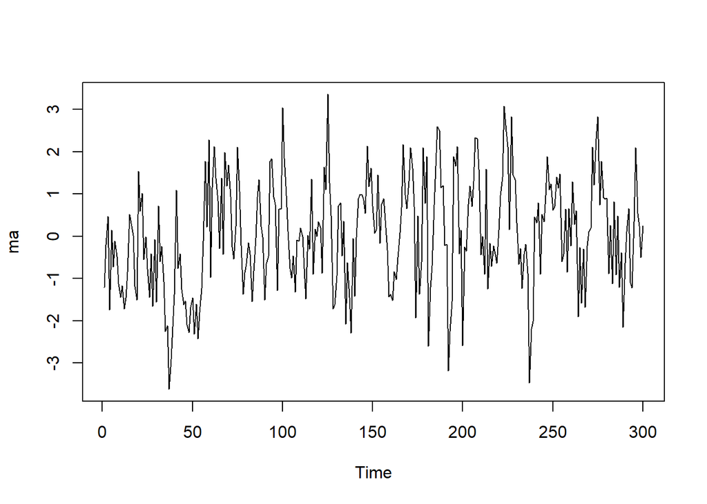

```r
ts.plot(ma)
```

### Plot ACF, PACF, EACF

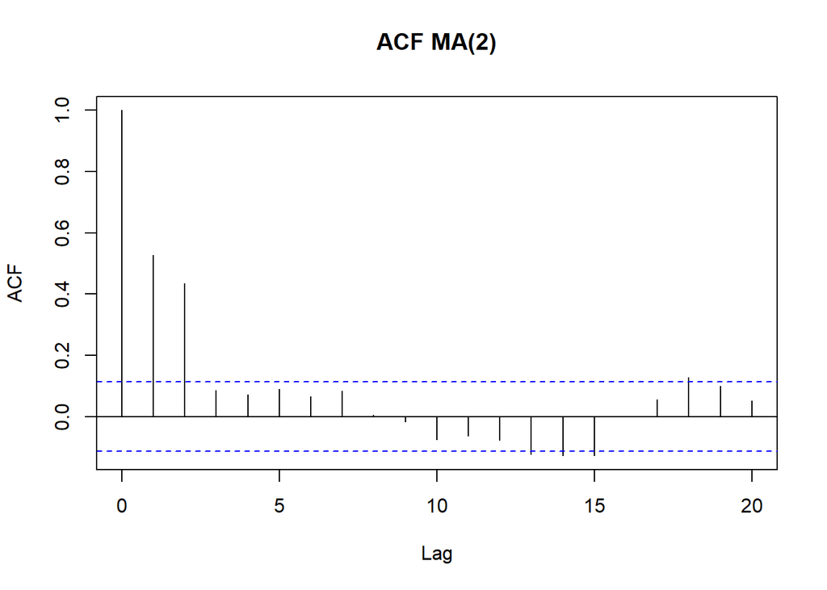

```r
acf(ma, lag.max = 20, main = "ACF MA(2)")
```

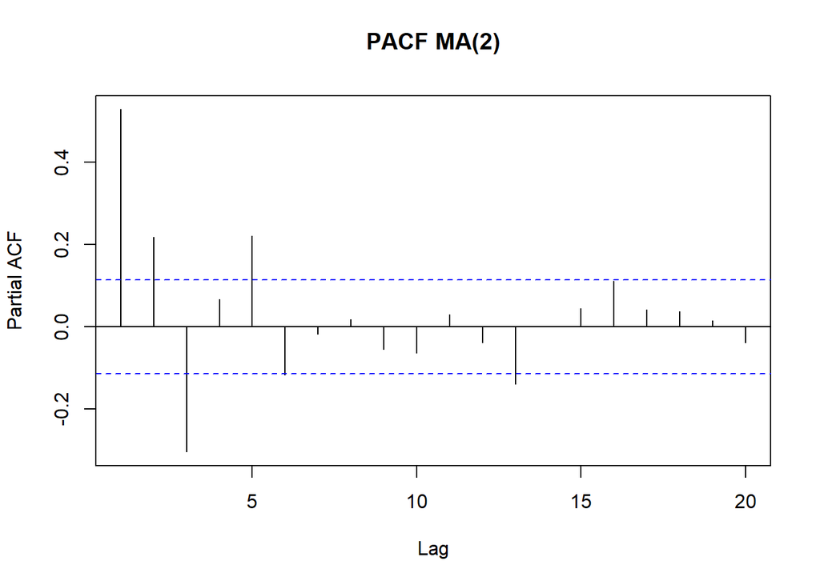

```r
pacf(ma, lag.max = 20, main = "PACF MA(2)")
```

```r
TSA::eacf(ma)
```

```
## AR/MA
##   0 1 2 3 4 5 6 7 8 9 10 11 12 13
## 0 x x o o o o o o o o o  o  x  x
## 1 x x x o o o o o o o o  o  o  o
## 2 x x x x o o o o o o o  o  o  o
## 3 x x x x x o o o o o o  o  o  o
## 4 x x x x x o o o o o o  o  o  o
## 5 x x o x x o x o o o o  o  o  o
## 6 x x x o x o o x o o o  o  o  o
## 7 x o x o x o o x o o o  o  o  o
```

### Plot Autokorelasi

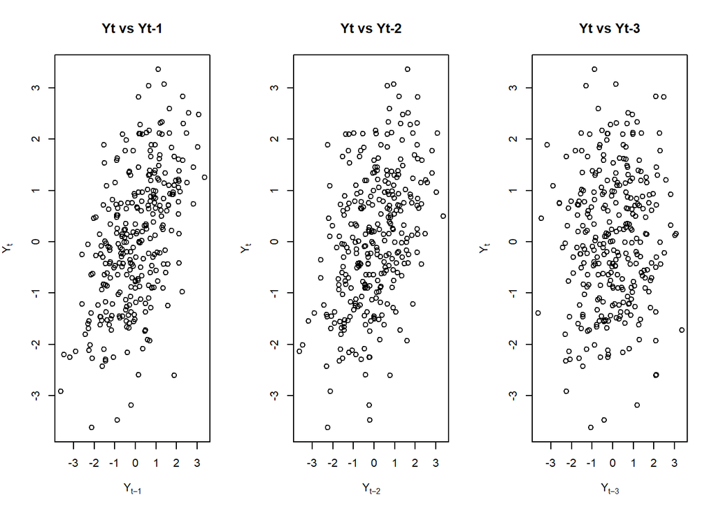

```r
# Data Lag
yt     <- ma[4:n]
yt_1   <- ma[3:(n - 1)]
yt_2   <- ma[2:(n - 2)]
yt_3   <- ma[1:(n - 3)]

par(mfrow = c(1, 3))
plot(yt_1, yt, main = "Yt vs Yt-1", xlab = expression(Y[t-1]), ylab = expression(Y[t]))
plot(yt_2, yt, main = "Yt vs Yt-2", xlab = expression(Y[t-2]), ylab = expression(Y[t]))
plot(yt_3, yt, main = "Yt vs Yt-3", xlab = expression(Y[t-3]), ylab = expression(Y[t]))
```

```r
par(mfrow = c(1, 1))

# Perbandingan Autokorelasi
rho_teori_ma <- c((0.4 + 0.4 * 0.6) / (1 + 0.4^2 + 0.6^2),
                  0.6 / (1 + 0.4^2 + 0.6^2),
                  0)
rho_sim_ma <- c(cor(yt, yt_1), cor(yt, yt_2), cor(yt, yt_3))

data.frame(Lag = 1:3, Teoritis = round(rho_teori_ma, 4), Sampel = round(rho_sim_ma, 4))
```

```
##   Lag Teoritis Sampel
## 1   1   0.4211 0.5288
## 2   2   0.3947 0.4374
## 3   3   0.0000 0.0854
```

# Proses Pembangkitan Data AR(2)

## Proses AR

Proses AR dapat dituliskan sebagai berikut:

$$y_{t} = c + e_t + \phi_{1}Y_{t-1} +
\phi_{2}Y_{t-2} + \dots + \phi_{q}Y_{t-q} = c+{e_t+\sum_{i=1}^p
\phi_iY_{t-i}}$$
Terlihat bahwa $Y_t$ berperan penting dalam pembangkitan proses AR.

## Pembangkitan Proses AR

Akan dicoba membangkitkan proses AR, yaitu AR(2) dengan $\phi_1 = 0.5$ dan $\phi_2 = 0.2$ sebanyak 300 observasi dan $c=0$.

```r
set.seed(1234)
```

Nilai-nilai selanjutnya dapat dicari melalui *loop*. Bentuk loop dapat dilihat dari rumus AR(2) yang hendak dibangkitkan:

$$Y_t = e_t+0.5Y_{t-1}+
0.2Y_{t-2}$$

```r
n <- length(wn)
ar <- numeric(n)

ar[1] <- wn[1]
ar[2] <- 0.5 * ar[1] + wn[2]

for (i in 3:n) {
  ar[i] <- 0.5 * ar[i - 1] + 0.2 * ar[i - 2] + wn[i]
}
ar
```

[output not shown]

[output cut: 45 more lines]

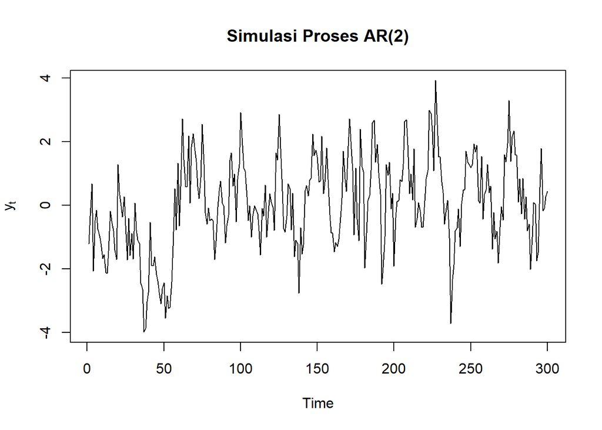

```r
ts.plot(ar, main = "Simulasi Proses AR(2)", ylab = expression(y[t]))
```

Selain menggunakan cara di atas, pembangkitan proses AR dapat dilakukan dengan fungsi `arima.sim()` sebagai berikut.

```r
set.seed(1234)
ar2_sim <- arima.sim(list(order = c(2, 0, 0), ar = c(0.5, 0.2)), n = n)
```

## Karakteristik AR(2)

### Plot Time Series

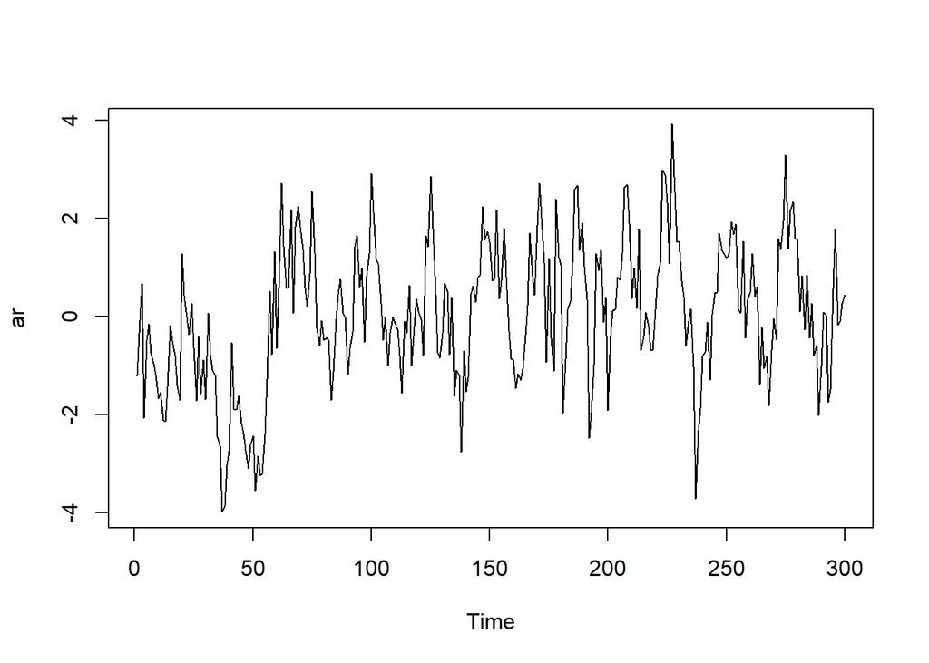

```r
ts.plot(ar)
```

Berdasarkan plot time series tersebut terlihat bahwa data cenderung stasioner pada rataan

### Plot ACF

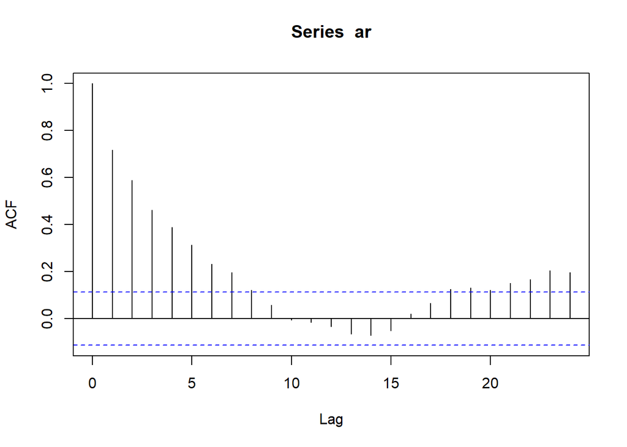

```r
acf(ar)
```

Berdasarkan plot ACF tersebut terlihat bahwa plot ACF cenderung *tails off* dan cenderung membentuk pola grafik sinus

### Plot PACF

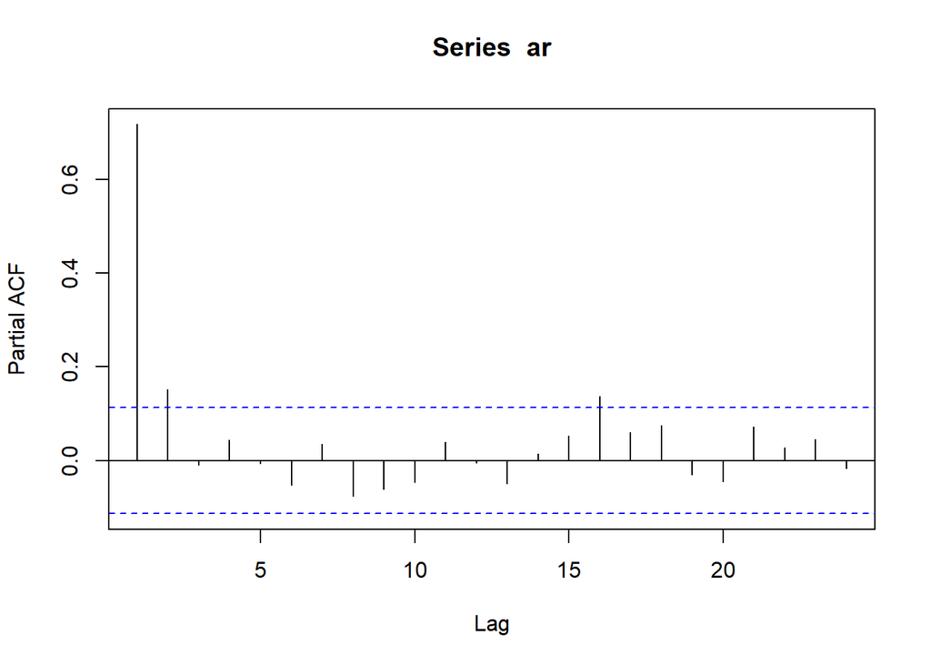

```r
pacf(ar)
```

### Plot EACF

```r
TSA::eacf(ar)
```

```
## AR/MA
##   0 1 2 3 4 5 6 7 8 9 10 11 12 13
## 0 x x x x x x x x o o o  o  o  o
## 1 x o o o o o o o o o o  o  o  o
## 2 o o o o o o o o o o o  o  o  o
## 3 x x o o o o o o o o o  o  o  o
## 4 x x o o o o o o o o o  o  o  o
## 5 o x o x o o x o o o o  o  o  o
## 6 x x x x o o o o o o o  o  o  o
## 7 x x x o x x o o o o o  o  o  o
```

### Scatterplot dan Autokorelasi antar Lag

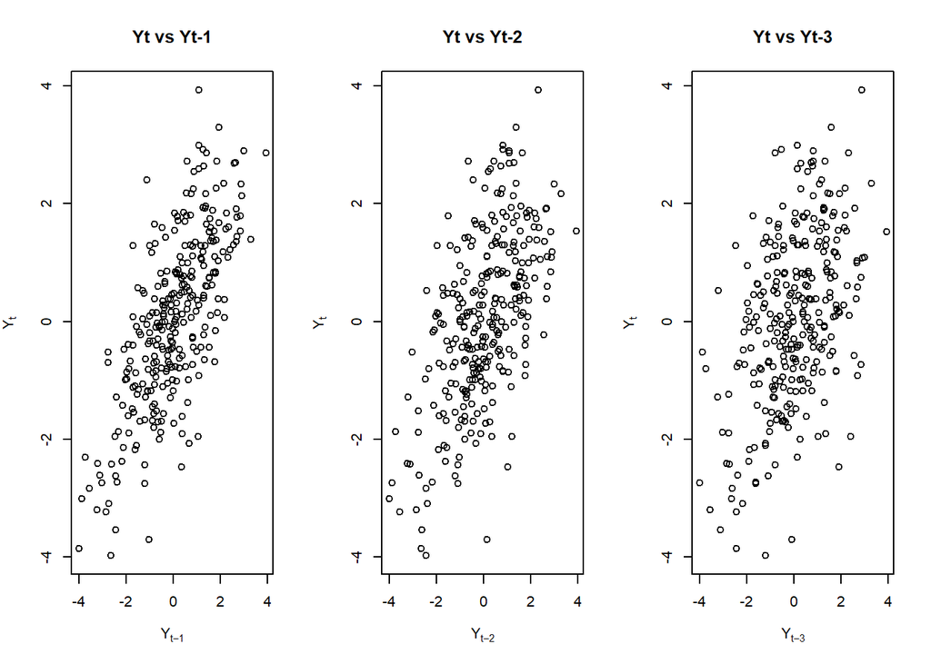

```r
yt_ar   <- ar[4:n]
yt_1_ar <- ar[3:(n - 1)]
yt_2_ar <- ar[2:(n - 2)]
yt_3_ar <- ar[1:(n - 3)]

par(mfrow = c(1, 3))
plot(yt_1_ar, yt_ar, main = "Yt vs Yt-1", xlab = expression(Y[t-1]), ylab = expression(Y[t]))
plot(yt_2_ar, yt_ar, main = "Yt vs Yt-2", xlab = expression(Y[t-2]), ylab = expression(Y[t]))
plot(yt_3_ar, yt_ar, main = "Yt vs Yt-3", xlab = expression(Y[t-3]), ylab = expression(Y[t]))
```

```r
par(mfrow = c(1, 1))

# Perbandingan Autokorelasi
rho_teori_ar <- ARMAacf(ar = c(0.5, 0.2), lag.max = 3)[-1]
rho_sim_ar <- c(cor(yt_ar, yt_1_ar), cor(yt_ar, yt_2_ar), cor(yt_ar, yt_3_ar))

data.frame(Lag = 1:3, Teoritis = round(rho_teori_ar, 4), Sampel = round(rho_sim_ar, 4))
```

```
##   Lag Teoritis Sampel
## 1   1   0.6250 0.7191
## 2   2   0.5125 0.5912
## 3   3   0.3812 0.4630
```

# Pembangkitan data ARMA (2,2)

## Pembangkitan Data Manual

```r
arma22 <- numeric(n)
arma22[1] <- wn[1]
arma22[2] <- 0.5 * arma22[1] + wn[2] + 0.4 * wn[1]

for (i in 3:n) {
  arma22[i] <- 0.5 * arma22[i - 1] + 0.2 * arma22[i - 2] +
                      wn[i] + 0.4 * wn[i - 1] + 0.6 * wn[i - 2]
}
```

## Pembangkitan Data dengan Fungsi `arima.sim()`

```r
set.seed(1234)
arma22_sim <- arima.sim(list(order = c(2, 0, 2), ar = c(0.5, 0.2), ma = c(0.4, 0.6)), n = n)
```

## Plot ACF, PACF, dan EACF

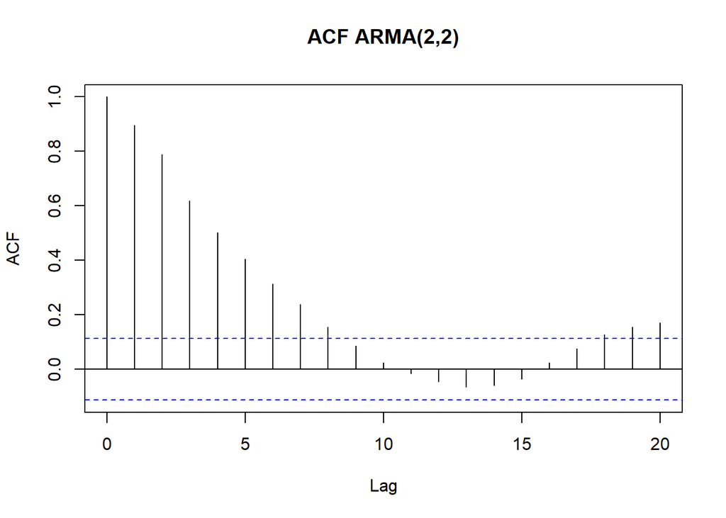

```r
acf(arma22, lag.max = 20, main = "ACF ARMA(2,2)")
```

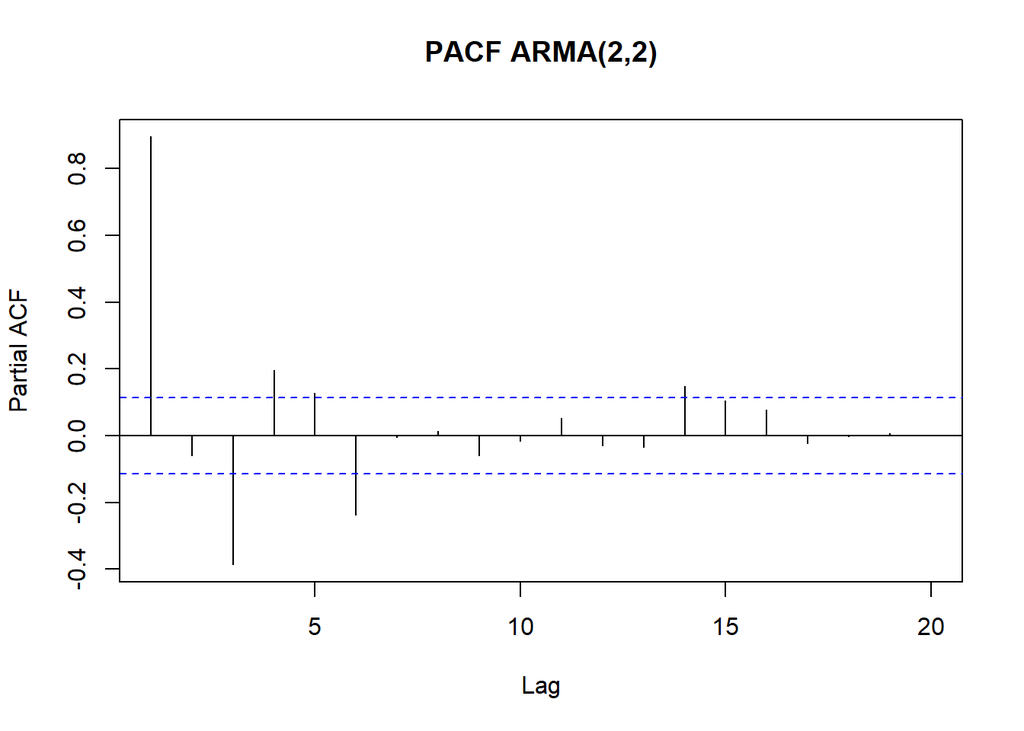

```r
pacf(arma22, lag.max = 20, main = "PACF ARMA(2,2)")
```

```r
TSA::eacf(arma22)
```

```
## AR/MA
##   0 1 2 3 4 5 6 7 8 9 10 11 12 13
## 0 x x x x x x x x o o o  o  o  o
## 1 o x o o o o x o o o o  o  o  o
## 2 x x o o o o x o o o o  o  o  o
## 3 x x o x o o x o o o o  o  o  o
## 4 x x x x o o x o o o o  o  o  o
## 5 x x x x x x x o o o o  o  o  o
## 6 o o x o x x o o o o o  o  o  o
## 7 o o x o x x o x o o o  o  o  o
```

## Scatterplot dan Autokorelasi antar Lag

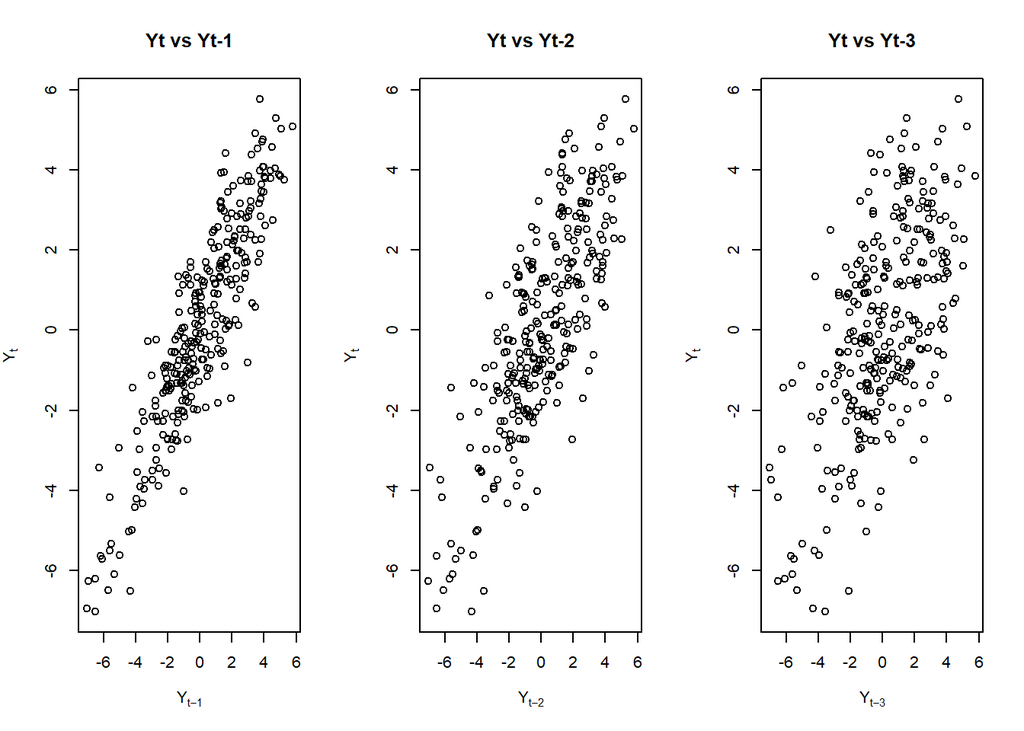

```r
yt_arma   <- arma22[4:n]
yt_1_arma <- arma22[3:(n - 1)]
yt_2_arma <- arma22[2:(n - 2)]
yt_3_arma <- arma22[1:(n - 3)]

par(mfrow = c(1, 3))
plot(yt_1_arma, yt_arma, main = "Yt vs Yt-1", xlab = expression(Y[t-1]), ylab = expression(Y[t]))
plot(yt_2_arma, yt_arma, main = "Yt vs Yt-2", xlab = expression(Y[t-2]), ylab = expression(Y[t]))
plot(yt_3_arma, yt_arma, main = "Yt vs Yt-3", xlab = expression(Y[t-3]), ylab = expression(Y[t]))
```

```r
par(mfrow = c(1, 1))

rho_teori_arma <- ARMAacf(ar = c(0.5, 0.2), ma = c(0.4, 0.6), lag.max = 10)

rho_sampel_arma <- acf(arma22, lag.max = 10, plot = FALSE)$acf[,,1]

perbandingan_acf <- data.frame(
  Lag = 0:10,
  ACF_Teori  = round(rho_teori_arma, 4),
  ACF_Sampel = round(rho_sampel_arma, 4),
  Selisih    = round(abs(rho_teori_arma - rho_sampel_arma), 4)
)

print(perbandingan_acf)
```

```
##    Lag ACF_Teori ACF_Sampel Selisih
## 0    0    1.0000     1.0000  0.0000
## 1    1    0.8592     0.8951  0.0359
## 2    2    0.7492     0.7894  0.0402
## 3    3    0.5464     0.6190  0.0726
## 4    4    0.4231     0.5024  0.0793
## 5    5    0.3208     0.4036  0.0828
## 6    6    0.2450     0.3136  0.0686
## 7    7    0.1867     0.2379  0.0513
## 8    8    0.1423     0.1539  0.0116
## 9    9    0.1085     0.0859  0.0226
## 10  10    0.0827     0.0232  0.0596
```

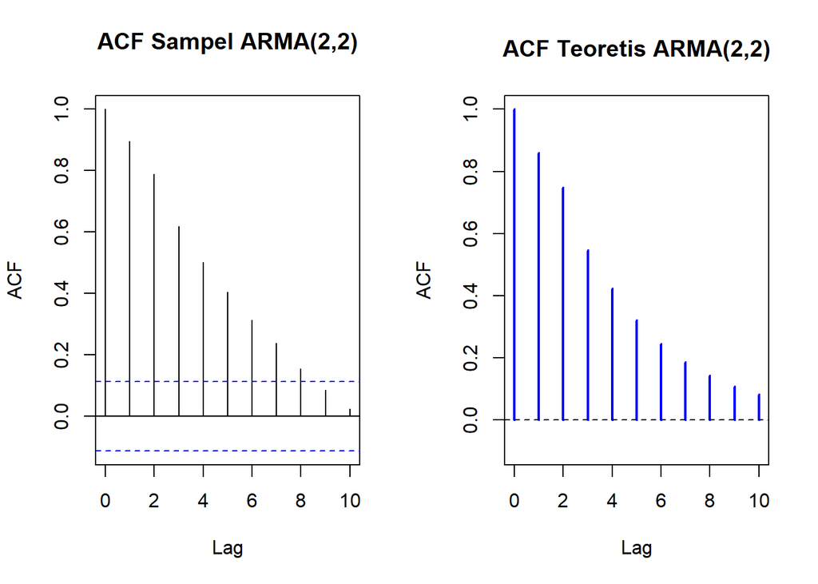

```r
par(mfrow = c(1, 2))
acf(arma22, lag.max = 10, main = "ACF Sampel ARMA(2,2)")
plot(0:10, rho_teori_arma, type = "h", lwd = 2, col = "blue",
     xlab = "Lag", ylab = "ACF", main = "ACF Teoretis ARMA(2,2)",
     ylim = c(min(rho_teori_arma, 0) - 0.1, 1))
abline(h = 0, lty = 2)
```

```r
par(mfrow = c(1, 1))
```